# Latte pappa - myth or reality?

### Abstract

My github activity is in free fall, my email response time is at least two days, and my stress level is lower than usual. What has happened, am I on vacation? Not quite, I’m in the middle of a five month parental leave with my almost one year old daughter Sophie. So far it’s been a joyful but also challenging time. Here are some thoughts about my own parental leave, about the conditions here in Sweden, and a comparison with other European countries.

### Latte pappa?!

How did I end up with **5 month of parental leave**? That might sound like an awful lot, and even more so in countries where institutional support for paternal leave is generally low. In Sweden, equal opportunities (and duties) for all genders is strongly encouraged, there is no specific maternal or paternal leave. The fact that dads can be spotted everywhere roaming the playground with their phone in one hand and a *latte* in the other (is that a word, latte?) gave rise to the friendly neologism ‘latte pappa’. Personally, I chose to take five months leave because it was in good agreement with my wife’s job situation and I wanted to spend as much time with the baby as possible. If this is above or below the Swedish average I actually didn’t know. But read on to find out.

**How does it work in Sweden formally?** Both parents can **share up to 480 days of paid leave.** Of those 480 days, 390 are ‘fully’ paid based on your pervious income (actually not fully but around 80%). The remaining 90 days are a basic flat rate of 180 SEK per day (~18 €). You can apply for support and **manage your account of days on line**. Not a single sheet of paper required. Very convenient.

**For comparison, parental leave in Germany** is paid for up to 14 months (420 days) that parents can share, at around 60 % of your previous income. A parent has to take at least two month to get the benefit. I often hear from friends that the kid’s mother takes tvelve months and the father just two, the bare minimum. We’ll have a look at the actual statistics below. Application for parental leave is paper based, requires you to hand in proof of your monthly income, and a personal visit in the city hall is likely. Not so convenient.

### Parental leave in Sweden and the EU

I wondered how many mums and dads actually take parental leave in the EU, and if the situation is different between member states. We can use the fantastic ´eurostats´ R package to see if there is central data available. There is!

```r
# attach packages
library(tidyverse)
library(eurostat)
library(lattice)
library(latticeExtra)
library(Rtools)
library(SysbioTreemaps)
```

```r
# search and download data from eurostats
search_eurostat("parental leave")
```

| title | code | type | last update of data | last table structure change | data start | data end | values |
| --- | --- | --- | --- | --- | --- | --- | --- |
| Persons who took parental leave to care for their youngest child aged less than eight, by duration of parental leave (1 000) | lfso_10lparlea | dataset | 16.02.2019 | 02.05.2019 | 2010 | 2010 | NA |

```r
df <- get_eurostat("lfso_10lparlea", type = "label", stringsAsFactors = FALSE)
head(df)
```

| unit | sex | age | duration | isced97 | geo | time | values |
| --- | --- | --- | --- | --- | --- | --- | --- |
| Thousand persons | Females | From 15 to 24 years | Zero months | Pre-primary, primary and lower secondary education (levels 0-2) | European Union - 28 countries | 2010-01-01 | 486.0 |
| Thousand persons | Females | From 15 to 24 years | Zero months | Upper secondary and post-secondary non-tertiary education (levels 3 and 4) | European Union - 28 countries | 2010-01-01 | 463.9 |
| Thousand persons | Females | From 15 to 24 years | Zero months | First and second stage of tertiary education (levels 5 and 6) | European Union - 28 countries | 2010-01-01 | 65.2 |
| Thousand persons | Females | From 15 to 24 years | Zero months | No response | European Union - 28 countries | 2010-01-01 | NA |
| Thousand persons | Females | From 15 to 24 years | Zero months | All ISCED 1997 levels | European Union - 28 countries | 2010-01-01 | 1018.5 |
| Thousand persons | Females | From 15 to 24 years | From 3 to 6 months | Pre-primary, primary and lower secondary education (levels 0-2) | European Union - 28 countries | 2010-01-01 | NA |

First I would like to take a lot at parental leave in Sweden, broken down by gender, age, and education. We will sum up all people that did parental leave regardless of the duration and look at the proportion of men and women. We need to reshape the data a bit by excluding summary values such as ‘all age grous’ or ‘all education levels’. We also exclude ‘zero months’ duration because that means no parental leave was taken, while we should include the ‘no response’ group ( where it’s not clear how long people were absent from work).

```r
# filter data for Sweden only, and remove summary values
df_swe <- filter(df,
  age != "From 15 to 64 years",
  geo == "Sweden",
  sex != "Total",
  isced97 != "All ISCED 1997 levels",
  duration != "Zero months",
  !is.na(values)
)

# abbreviate lengthy description
df_swe <- mutate(df_swe,
  age = gsub("From | years", "", age),
  education = c("tertiary", "no response",
    "primary", "secondary")[factor(isced97) %>% as.numeric]
)
```

For the fun of it we can plot the data in a treemap representation. It’s not ideal for every type of data but here it works fairly well. We plot it using my [**SysbioTreemaps**](https://github.com/m-jahn/SysbioTreemaps) R package that can plot nested Voronoi and Sunburst treemaps from a `data.frame`. Both representations tell the same story, that men and women take equally often parental leave, although we do not know how long.

```r
# generate treemaps
# ---------------------------------
# parental leave as Voronoi treemap
tm <- voronoiTreemap(
  data = df_swe,
  levels = c("sex", "age", "education"),
  cell_size = "values",
  shape = "circle",
  error_tol = 0.001,
  maxIteration = 200,
  positioning = "regular"
)
```

```
Level 1 tesselation:  0.08 % mean error,  0.08 % max error,  1 iterations
Level 2 tesselation:  0.06 % mean error,  0.1 % max error,  175 iterations
Level 3 tesselation:  0.07 % mean error,  0.1 % max error,  62 iterations
Level 3 tesselation:  0.06 % mean error,  0.09 % max error,  89 iterations
Level 3 tesselation:  0.09 % mean error,  0.13 % max error,  200 iterations
Level 2 tesselation:  0.07 % mean error,  0.1 % max error,  161 iterations
Level 3 tesselation:  0.05 % mean error,  0.09 % max error,  59 iterations
Level 3 tesselation:  0.06 % mean error,  0.1 % max error,  100 iterations
Level 3 tesselation:  0.07 % mean error,  0.1 % max error,  97 iterations
Treemap successfully created
```

```r
# parental leave as Sunburst treemap
tm2 <- sunburstTreemap(
  data = df_swe,
  levels = c("sex", "age", "education"),
  cell_size = "values"
)
```

```
Treemap successfully created
```

```r
# draw generated treemaps
# ---------------------------------
drawTreemap(
  tm,
  label_level = 1:3,
  label_size = 1.5,
  label_color = c(grey(0.95), grey(0.8), grey(0.5)),
  border_size = 8,
  legend = TRUE,
  title = "Number of parents taking leave for first kid, Eurostat 2010",
  layout = c(1, 2),
  position = c(1, 1)
)
```

```
Use 'add = TRUE' if you want to add more treemaps to this page.
```

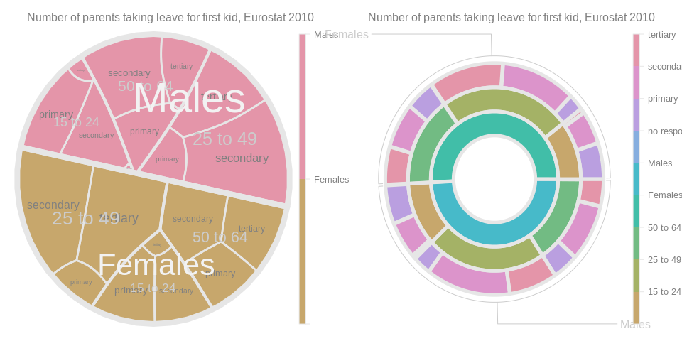

```r
drawTreemap(
  tm2,
  label_level = 1,
  label_color = grey(0.8),
  border_size = 5,
  legend = TRUE,
  title = "Number of parents taking leave for first kid, Eurostat 2010",
  layout = c(1, 2),
  position = c(1, 2),
  add = TRUE
)
```

This data set is a good example for rich annotation because it contains several variables of metadata that we can use to interrogate it. **We can plot parental leave broken down by country, age, gender, duration**, and so on. Or everything at once (that would be messy). I initially wondered about mums and dads taking different duration of parental leave, and assumed that **the gender gap might be smaller in Sweden than in other EU contries**. Now it’s time to find out.

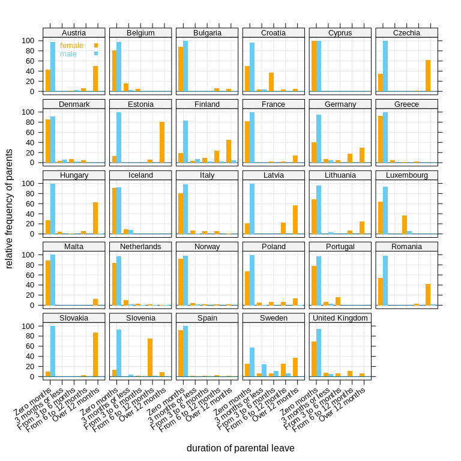

```r
# filter for all EU countries and summary
# values for age and education
df_mod <- filter(df,
  age == "From 15 to 64 years",
  !grepl("Euro", geo),
  sex != "Total",
  isced97 == "All ISCED 1997 levels",
  !duration %in% c("No response", "Ongoing", "Not applicable")
)

# change order of factor duration
df_mod <- mutate(df_mod,
  duration = factor(duration, unique(duration)[c(1,3,2,4,5)])
)

# turn absolute number of parents to relative
df_mod <- mutate(df_mod, geo = gsub(" .until.*", "", geo)) %>%
  group_by(geo, sex) %>%
  mutate(rel_frequency = 100*values/sum(values, na.rm = TRUE))

# parental leave
xyplot(rel_frequency ~ factor(duration) | geo,
  df_mod, col = c("orange", "#65CCF5"),
  groups = sex, as.table = TRUE,
  between = list(x = 0.4, y = 0.4),
  par.settings = custom.lattice(),
  xlab = "duration of parental leave",
  ylab = "relative frequency of parents",
  scales = list(alternating = FALSE, x = list(rot = 35)),
  panel = function(x, y, ...) {
    panel.grid(h = -1, v = -1, col.line = grey(0.9))
    panel.barchart(x, y, horizontal = FALSE, origin = 0, stack = FALSE,
      border = NA, box.width = 0.8, ...)
    panel.key(c("female", "male"), col = c("orange", "#65CCF5"), pch = 15,
      corner = c(0.9, 0.9))
  }
)
```

Well, the result is… disappointing. The blue bars are dads taking parental leave broken down by EU member state, and **the overwhelming majority of men take no parental leave at all**. Sweden and Finland seem to be the top countries regarding paternal leave. But even in Sweden, most men don’t take parental leave and the number of dads that do drops with increasing duration.

The surprising finding is that even **many mothers don’t take any maternal leave**. Bulgaria, Cyprus, Denmark, Greece, Iceland, who takes care of your babies during the first year? If you know the answer please leave a comment. What is very well possible is that the data presented here is outdated (2010) or that some groups are not accurately annotated, e.g. if a member state doesn’t collect or report data on duration of parental leave to Eurstat.